# Complete Data Analysis workflow for scRNAseq data

Anne Hoffrichter

2020/11/26

# 1 Goal

Complete data analysis from count matrix to files used for figures.

# 2 Approach

```r
library(Seurat)
library(viridis)
library(Matrix)
library(SingleCellExperiment)
library(scater)
library(DESeq2)
library(neuMatIdx)
library("AnnotationDbi")
library("org.Hs.eg.db")
library(monocle3)
library(SeuratWrappers)
library(tidyverse)
library(purrr)
library(grid)
library(patchwork)
library(limma)
set.seed(42)
```

## 2.1 Filtering

The raw data is filtered on various properties. The output of cellranger [10x Genomics] count is read into R. First filtering parameters are determined, later filtering is performed in a Seurat S4 object.

```r
# Paths to the cellbarcode, features (genenames) and count matrix (molecules)
# files.
cellbarcodes <- read.table("../raw_data/filtered_feature_bc_matrix/barcodes.tsv")
genenames <- read.table("../raw_data/filtered_feature_bc_matrix/features.tsv")
molecules <- readMM("../raw_data/filtered_feature_bc_matrix/matrix.mtx")
```

```r
rownames(molecules) <- genenames[, 1]
colnames(molecules) <- cellbarcodes[, 1]
umi <- SingleCellExperiment(assays = list(counts = as.matrix(molecules)))
```

### 2.1.1 Filter genes without any counts

Genes that are not expressed in any cell are removed before the analysis.

```r
keep_feature <- rowSums(counts(umi) > 0) > 0
umi <- umi[keep_feature, ]
```

### 2.1.2 Cell QC Library size

Consider the total number of RNA molecules detected per sample. “Cells” with few molecules were most probably empty droplets and should be removed. Data should be normal-distributed, anything that appears on the left end outside the normal distribution, should be removed before analysis.

```r
umi <- perCellQCMetrics(umi)
```

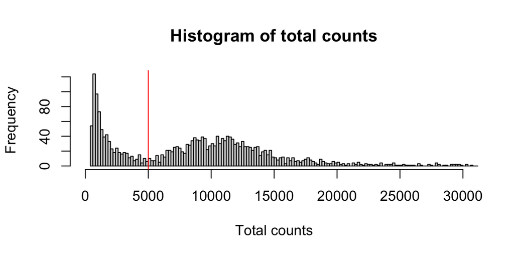

```r
hist(umi$total, breaks = 400, xlim = range(1:30000), main = "Histogram of total counts",
    xlab = "Total counts")
abline(v = 5000, col = "red")
```

Check how many cells will be kept (TRUE)/ removed (FALSE) by the filter:

```r
filter_by_total_counts <- (umi$total > 5000)
table(filter_by_total_counts)
```

```
## filter_by_total_counts
## FALSE  TRUE
##   720  1539
```

### 2.1.3 Filter for detected genes

In addition to ensuring sufficient sequencing depth for each sample, we also want to make sure that the reads are distributed across the transcriptome. Thus, we count the total number of unique genes detected in each sample. If detection rates were equal across the cells then the distribution should be approximately normal. Thus those cells in the left tail of the distribution should be removed.

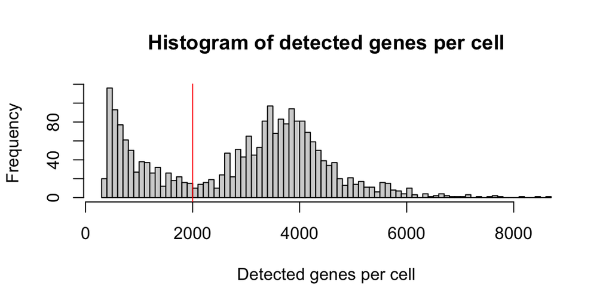

```r
hist(umi$detected, breaks = 100, main = "Histogram of detected genes per cell", xlab = "Detected genes per cell")
abline(v = 2000, col = "red")
```

Check how many cells will be kept (TRUE)/ removed (FALSE) by the filter:

```r
filter_by_expr_features <- (umi$detected > 2000)
table(filter_by_expr_features)
```

```
## filter_by_expr_features
## FALSE  TRUE
##   686  1573
```

### 2.1.4 Add QC counts for mitochondrial (MT) genes

Control features for MT genes are defined and quality metrics calculated. A high expression of mitochondrial genes can indicate apoptotic cells.

```r
umi <- SingleCellExperiment(assays = list(counts = as.matrix(molecules)))
keep_feature <- rowSums(counts(umi) > 0) > 0
umi <- umi[keep_feature, ]
altExp(umi, "MT") <- umi[rownames(umi) %in% c("ENSG00000198899", "ENSG00000198727",
    "ENSG00000198888", "ENSG00000198886", "ENSG00000212907", "ENSG00000198786", "ENSG00000198695",
    "ENSG00000198712", "ENSG00000198804", "ENSG00000198763", "ENSG00000228253", "ENSG00000198938",
    "ENSG00000198840"), ]

umi <- perCellQCMetrics(umi, use_altexps = TRUE)
```

Check distribution of MT-genes

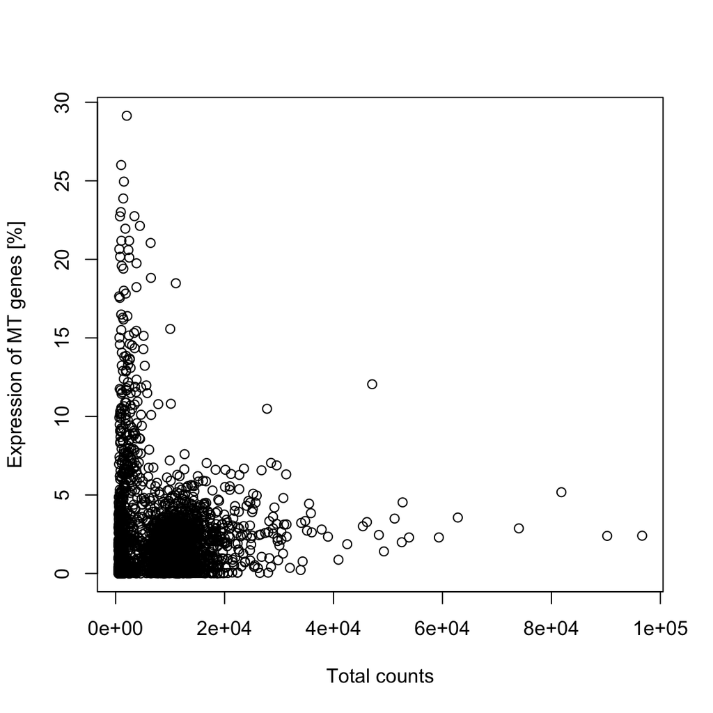

```r
plot(umi$total, umi$altexps_MT_percent, ylab = "Expression of MT genes [%]", xlab = "Total counts")
```

Check how many cells will be kept (TRUE)/ removed (FALSE) by the filter:

```r
filter_by_MT <- umi$altexps_MT_percent < 10
table(filter_by_MT)
```

```
## filter_by_MT
## FALSE  TRUE
##    94  2165
```

```r
# remove everything from global env
rm(list = ls())
```

Save parameters for filtering, as deduced from visual inspection of the different distributions.

```r
param <- list()
param$total_counts <- 5000
param$expr_features <- 2000
param$MT <- 10
```

## 2.2 Filtering the data with Seurat

```r
ctrl.rawdata <- Read10X(data.dir = "../raw_data/filtered_feature_bc_matrix/")
```

### 2.2.1 Set up Seurat object

Cells are at this step filtered for the minimum of expressed features. Features are only kept when they are expressed in a minimum of 3 cells.

```r
ctrl <- CreateSeuratObject(counts = ctrl.rawdata, min.cells = 3, min.features = param$expr_features,
    project = "boost")
ctrl$KO <- "CTRL"
ctrl[["percent.mt"]] <- PercentageFeatureSet(object = ctrl, pattern = "^MT-")
```

### 2.2.2 Filter cells

Use for colSums > cut-off in `total_counts`, for percent.mt `MT`

```r
ctrl <- subset(x = ctrl, subset = colSums(ctrl) > param$total_counts & percent.mt <
    param$MT)
ctrl <- NormalizeData(object = ctrl, verbose = FALSE)
ctrl <- FindVariableFeatures(object = ctrl, selection.method = "vst", nfeatures = 2000)
```

## 2.3 SCTransform

`SCTransform` uses regularized negative binomial regression to normalize UMI count data.

```r
boost <- SCTransform(ctrl, verbose = FALSE)
```

```r
rm(ctrl.rawdata, ctrl, param)
```

## 2.4 Use bulk RNAseq marker for PCA

Load data from bulk RNAseq project. Select variable features for each time point (d0/progenitors, d5, d25, d45, d25&d45).

The variable features for each time point were selected, so that the padj-value was at least less than 0.1 and so that there were not more than 1000 variable features per time point. There were also variable features selected for combining d25 & d45, as these two time points show only few variable features by themselves, as their expression profiles are very similar.

```r
# set path to results from RNAseq project
res <- readRDS("../../bulk/data/res.rds")
```

```r
d0_markers <- map(res[1:3], ~.x %>% as.data.frame() %>% filter(padj < 10^-18 & log2FoldChange <
    0) %>% .$gene_symbol)
d0_123 <- purrr::reduce(d0_markers, dplyr::intersect)
```

```r
d5_markers <- map(res[4:6], ~.x %>% as.data.frame() %>% filter(padj < 0.05 & log2FoldChange <
    0) %>% .$gene_symbol)
d5_123 <- purrr::reduce(d5_markers, dplyr::intersect)
```

```r
d25_markers <- map(res[7:9], ~.x %>% as.data.frame() %>% filter(padj < 0.1 & log2FoldChange <
    0) %>% .$gene_symbol)
d25_123 <- purrr::reduce(d25_markers, dplyr::intersect)
```

```r
d45_markers <- map(res[10:12], ~.x %>% as.data.frame() %>% filter(padj < 0.1 & log2FoldChange <
    0) %>% .$gene_symbol)
d45_123 <- purrr::reduce(d45_markers, dplyr::intersect)
```

```r
d25_45_markers <- map(res[c(7, 8, 10, 11)], ~.x %>% as.data.frame() %>% filter(padj <
    5e-04 & log2FoldChange < 0) %>% .$gene_symbol)
d25_45_123 <- purrr::reduce(d25_45_markers, dplyr::intersect)
```

```r
genes <- c(d0_123, d5_123, d25_123, d45_123, d25_45_123)
```

```r
rm(d0_markers, d5_markers, d25_markers, d45_markers, d25_45_markers, d0_123, d5_123,
    d25_123, d45_123, d25_45_123)
```

### 2.4.1 Scale data including all features

```r
DefaultAssay(boost) <- "RNA"
boost <- ScaleData(boost, features = row.names(boost))
```

### 2.4.2 Use marker genes from bulk data as features for guiding PCA

```r
boost <- RunPCA(boost, verbose = FALSE, features = genes)
```

## 2.5 Dimensional reduction and clustering

```r
boost <- RunUMAP(boost, dims = 1:30, verbose = FALSE)
boost <- FindNeighbors(boost, dims = 1:50, k.param = 30)
boost <- FindClusters(boost, verbose = F, resolution = 1)
```

Changing the names of the clusters to better represent their order in pseudotime.

```r
new_order <- c("4", "5", "2", "6", "3", "1")
names(new_order) <- levels(boost)
boost <- RenameIdents(boost, new_order)
boost <- AddMetaData(boost, Idents(boost), col.name = "new_order")
order_new_order <- c("1", "2", "3", "4", "5", "6")
Idents(boost) <- factor(Idents(boost), levels = order_new_order)
boost$new_order <- factor(boost$new_order, levels = order_new_order)
```

## 2.6 Add NMI information to Seurat data

The neuron maturity index (NMI) is estimated using the `neuMatIdx` package.

```r
# NMI
mat <- as.matrix(boost@assays$RNA@data)
```

```r
symbl <- rownames(mat)
ensmbl <- mapIds(org.Hs.eg.db, keys = symbl, column = "ENSEMBL", keytype = "SYMBOL",
    multiVals = "first")
ensml2 <- as.vector(ensmbl)
rownames(mat) <- ensml2
```

```r
rn <- rownames(mat)
xx <- is.na(rn)
df <- mat[!xx, ]
```

```r
NMI <- predictNMI(df)
```

```r
boost$NMIoverall <- NMI$overallNMI$overall
boost$NMIdiscriminable <- NMI$overallNMI$discriminable
boost$NMIactivity <- NMI$overallNMI$activity
```

```r
rm(list = setdiff(ls(), "boost"))
```

## 2.7 Adding pseudotime trajectory with monocle3

```r
# boost_subset <- subset(boost, new_order%in%c('1', '2', '3', '4', '5'))
cds <- as.cell_data_set(boost)

sf <- rep(1, length(colData(cds)$KO))
names(sf) <- colnames(cds)
colData(cds)$Size_Factor <- sf

cds <- cluster_cells(cds)
cds <- learn_graph(cds)
# long_branch.sub <- subset(as.Seurat(cds), monocle3_clusters == 1)
# short_branch.sub <- subset(as.Seurat(cds), monocle3_clusters == 2) cds_long <-
# as.cell_data_set(long_branch.sub) cds_long <- learn_graph(cds_long) cds_long <-
# order_cells(cds_long) # choose 7th point from bottom, click 'choose/unchose',
# point turns red, then click 'done' cds_short <-
# as.cell_data_set(short_branch.sub) cds_short <- learn_graph(cds_short) #
# FeaturePlot(short_branch.sub, features=c('MKI67', 'SOX2', 'HES1', 'NES'))
# cds_short <- order_cells(cds_short) # use point lowest left, point turns red,
# then click 'done' saveRDS(cds_long, '../data/long_branch_cells.rds')
# saveRDS(cds_short, '../data/short_branch_cells.rds')
```

```r
long_branch <- readRDS("../data/long_branch_cells.rds")
```

```r
short_branch <- readRDS("../data/short_branch_cells.rds")
```

```r
rowData(long_branch)$gene_short_name <- rownames(rowData(long_branch))
rowData(short_branch)$gene_short_name <- rownames(rowData(short_branch))
```

Combining pseudotimes of short and long branch by adding the maximum value of the short branch to each value of the long branch. Marker gene expression indicates, that cells in the short branch are from earlier time points, compared to cells in the long branch.

```r
long_branch@principal_graph_aux@listData$UMAP$pseudotime <- long_branch@principal_graph_aux@listData$UMAP$pseudotime +
    max(short_branch@principal_graph_aux@listData$UMAP$pseudotime)
```

```r
boost$pseudotime <- c(long_branch@principal_graph_aux@listData$UMAP$pseudotime, short_branch@principal_graph_aux@listData$UMAP$pseudotime)

cds@principal_graph_aux@listData$UMAP$pseudotime <- c(long_branch@principal_graph_aux@listData$UMAP$pseudotime,
    short_branch@principal_graph_aux@listData$UMAP$pseudotime)

rowData(cds)$gene_short_name <- rownames(rowData(cds))
saveRDS(boost, "../data/boost_data_seurat.rds")
saveRDS(cds, "../data/boost_data_cds.rds")
```

```r
rm(list = setdiff(ls(), c("boost", "cds")))
```